# WHO Notebook

```r
#install.packages("ggplot2")
```

One of the advantages of software such as R is that you can add and install packages that provided added functionality. The `ggplot2` packages is one such package that improves on the basic plotting in R. In this package, you build a graph by adding layer upon layer where you specify the data, aesthetic mapping, statistical transformations (if any) and geometric object (type of plot).

We will use a data set from http://www.who.int/gho/en. The dataset contains data on 194 countries from WHO where the variables are: 1. Country - name of country, 2. Region - region the country lies in, 3. Population - population in thousands, 4. Under15 - Percentage of the population under 15 years of age, 5. Over60 - Percentage of the population over 60 years of age, 6. FertilityRate - Average number of children per woman, 7. LifeExpectancy - Life expectancy in years, 8. LiteracyRate - Literacy rate among adults at least 15 years of age, 9. GNI - Gross national income per capita

First we have a look at the data set

```r
library(ggplot2)
WHO <- read.csv("WHO.csv")
str(WHO)
```

```
## 'data.frame':    194 obs. of  9 variables:
##  $ Country       : chr  "Afghanistan" "Albania" "Algeria" "Andorra" ...
##  $ Region        : chr  "Eastern Mediterranean" "Europe" "Africa" "Europe" ...
##  $ Population    : int  29825 3162 38482 78 20821 89 41087 2969 23050 8464 ...
##  $ Under15       : num  47.4 21.3 27.4 15.2 47.6 ...
##  $ Over60        : num  3.82 14.93 7.17 22.86 3.84 ...
##  $ FertilityRate : num  5.4 1.75 2.83 NA 6.1 2.12 2.2 1.74 1.89 1.44 ...
##  $ LifeExpectancy: int  60 74 73 82 51 75 76 71 82 81 ...
##  $ LiteracyRate  : num  NA NA NA NA 70.1 99 97.8 99.6 NA NA ...
##  $ GNI           : num  1140 8820 8310 NA 5230 ...
```

```r
which(WHO$Country=="Singapore")
```

```
## [1] 155
```

```r
WHO[155,]
```

```
##       Country          Region Population Under15 Over60 FertilityRate
## 155 Singapore Western Pacific       5303   16.48  15.13          1.27
##     LifeExpectancy LiteracyRate   GNI
## 155             82         95.9 59380
```

```r
summary(WHO$Over60)
```

```
##    Min. 1st Qu.  Median    Mean 3rd Qu.    Max.
##    0.81    5.20    8.53   11.16   16.69   31.92
```

```r
summary(WHO$Under15)
```

```
##    Min. 1st Qu.  Median    Mean 3rd Qu.    Max.
##   13.12   18.72   28.65   28.73   37.75   49.99
```

**Singapore** has a high fraction of population over 60 and low fraction of population under 15 as compared to many countries - ageing population and low fertility rate issues.

#### Visualisation

Let us see how many countries are there in each region

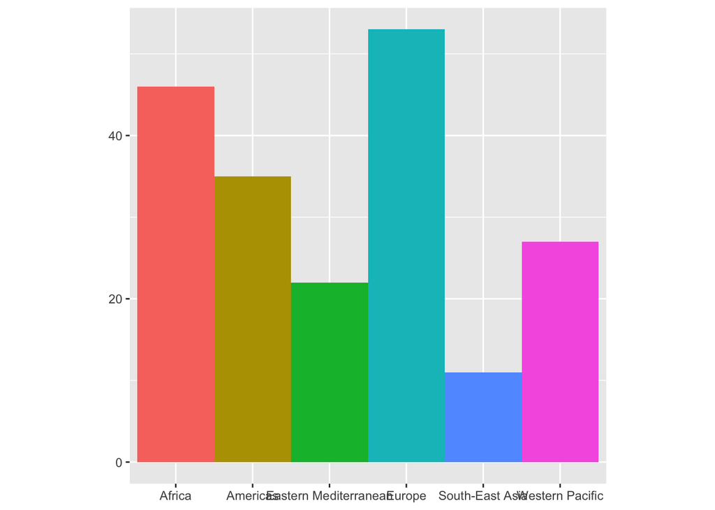

```r
bar <- ggplot(WHO) + geom_bar(mapping = aes(x = Region, fill = Region), show.legend = FALSE, width = 1) +  theme(aspect.ratio = 1) + labs(x = NULL, y = NULL)
bar
```

Now we compare the following

We also subgroup by region sometimes

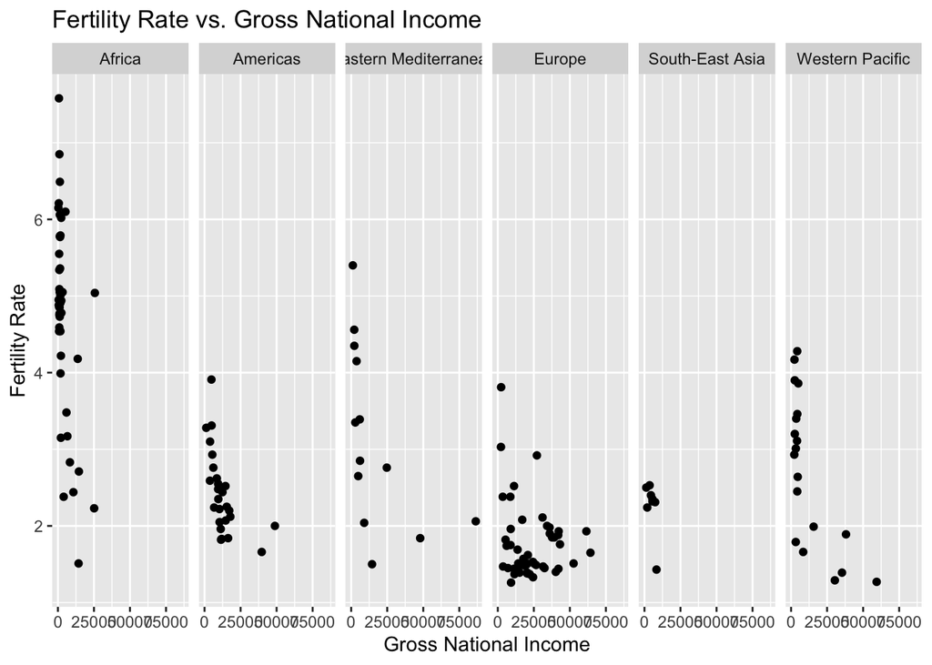

```r
a<-ggplot(WHO,aes(x=GNI,y=FertilityRate))

a+geom_point(na.rm=TRUE)+facet_grid(.~Region)+ ggtitle("Fertility Rate vs. Gross National Income") + xlab("Gross National Income") + ylab("Fertility Rate")
```

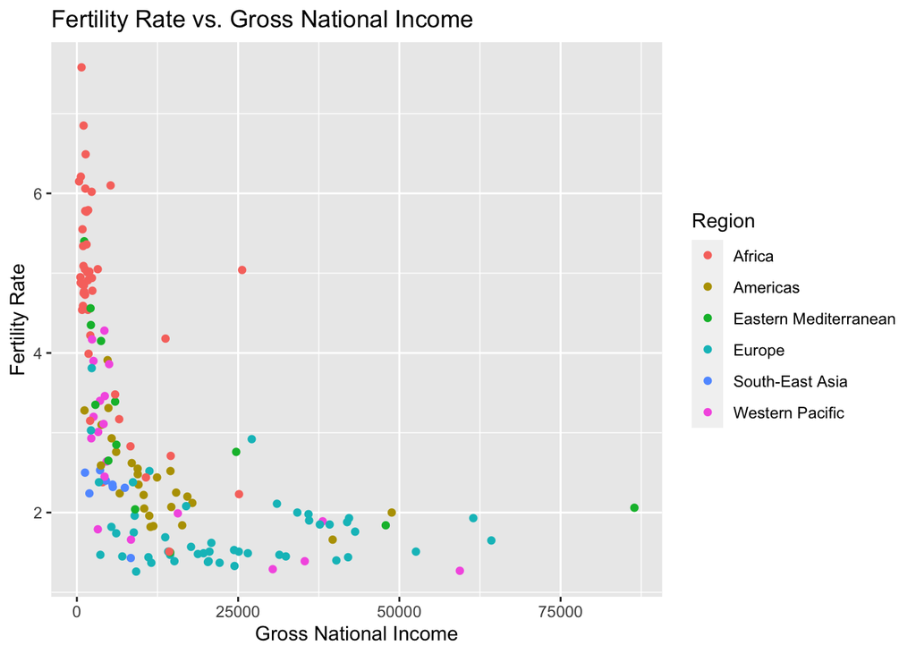

```r
 #facet_grid will give different regions, plots separated based on the region

#  a+geom_point(na.rm=TRUE)+geom_smooth(na.rm=TRUE)+ ggtitle("Fertility Rate vs. Gross National Income") + xlab("Gross National Income") + ylab("Fertility Rate")

# color by region
acol <- ggplot(WHO,aes(x=GNI,y=FertilityRate, color=Region))

 acol+geom_point(na.rm=TRUE)+ ggtitle("Fertility Rate vs. Gross National Income") + xlab("Gross National Income") + ylab("Fertility Rate")
```

```r
#  acol+geom_point(na.rm=TRUE)+geom_smooth(na.rm=TRUE)+ ggtitle("Fertility Rate vs. Gross National Income") + xlab("Gross National Income") + ylab("Fertility Rate")
#

#  a+geom_point(na.rm=TRUE)+facet_wrap(~Region,nrow=2)+ ggtitle("Fertility Rate vs. Gross National Income") + xlab("Gross National Income") + ylab("Fertility Rate")
# #
# #
# b<-ggplot(WHO,aes(x=GNI,y=LiteracyRate,color=Region))+ggtitle("Literacy Rate vs. Gross National Income") + xlab("Gross National Income") + ylab("Fertility Rate")
#
# b+geom_point(na.rm=TRUE)

#  subset(WHO,GNI>75000)
# #
#  WHOL<-subset(WHO,LiteracyRate>90)
# #
# c<-ggplot(WHOL,aes(x=GNI,y=LiteracyRate,color=Region))
#
# c+geom_point(na.rm=TRUE)+ggtitle("Literacy Rate vs. Gross National Income (top 90 percent literacy)") + xlab("Gross National Income") + ylab("Fertility Rate")


#
# d<-ggplot(WHO,aes(x=GNI,y=LifeExpectancy,color=Region))
# d+geom_point(na.rm=TRUE)+ggtitle("Literacy Rate vs. Gross National Income") + xlab("Gross National Income") + ylab("Life Expectancy")
# ggplot(WHO,aes(x=GNI,y=LifeExpectancy))+geom_point(na.rm=TRUE)+ facet_wrap(~Region,nrow=2)+ggtitle("Literacy Rate vs. Gross National Income") + xlab("Gross National Income") + ylab("Life Expectancy")
#
```